# Webscraping Final Assignment

Istvan Janco

12/20/2021

# Overview

The aim of this project is to scrape data on USA- based basketball teams from basketballreference.com and conduct a quick analysis on teams stats.

# Getting and Manipulating the Data

Calling the packages.

```r
# load packages
library(rvest)
library(data.table)
library(xml2)
library(kableExtra)
library(ggplot2)
library(dplyr)
library(tibble)
library(stringr)
```

```r
# define the url
url <- "https://www.basketball-reference.com/teams/"

t <- read_html(url)

# create data list
data_list <- list()

# get teams statistics
data_list[["stats"]]<- t %>%
  html_nodes("td") %>%
  html_text()

# convert the list to a df
df <- as.data.frame(data_list)

# transposing the df and name the columns
df_stats <- as.data.frame(matrix(df$stats, ncol=12, byrow=TRUE))
names(df_stats) <- c("league", "from", "to", "yrs", "games", "wins", "losses",
                    "win/lose%",  "playoffs", "division_wins", "conference_wins",
                    "championships")

# replace all the empty cells with 0
df_stats <- as.data.frame(sapply(df_stats , gsub , pattern = "^\\s*$" , replacement = 0 ))

# get team names
data_list1 <- list()

data_list1[["name"]]<- t %>%
  html_nodes("th") %>%
  html_text()

# create a list
df1 <- as.data.frame(data_list1)

# delete the column names from the retrieved data
df_names <- data.frame(df1[!(df1$name=="Franchise" | df1$name=="Lg" | df1$name=="From" | df1$name=="Yrs"
         | df1$name=="To" | df1$name=="G" | df1$name=="W" | df1$name=="L"| df1$name=="W/L%"
         | df1$name=="Plyfs" | df1$name=="Div" | df1$name=="Conf" | df1$name=="Champ") , ])

#rename the column
df_names <- df_names %>%
  transmute(teams = df_names$df1...df1.name.....Franchise....df1.name.....Lg....df1.name....)


# bind the sats and the team names
df_fin <- cbind(df_names, df_stats)

# quick cleanup on final df
df_nba <- df_fin %>% mutate(yrs = as.numeric(yrs),
                            games = as.numeric(games),
                            wins = as.numeric(wins),
                            losses = as.numeric(losses),
                            `win/lose%` = as.numeric(`win/lose%`),
                            playoffs = as.numeric(playoffs),
                            division_wins = as.numeric(division_wins),
                            conference_wins = as.numeric(conference_wins),
                            championships = as.numeric(championships))
```

# Creating a Function

After getting the data for the male-leagues, we use the same logic, we create a function to get the same data for WNBA.

```r
# creating a function to scrape the same data but for WNBA teams

get_wnba <- function(url) {

  t <- read_html(url)

  # create data list
  data_list <- list()

  # get teams statistics
  data_list[["stats"]]<- t %>%
    html_nodes("td") %>%
    html_text()

  df <- as.data.frame(data_list)

  df_stats <- as.data.frame(matrix(df$stats, ncol=11, byrow=TRUE))
  names(df_stats) <- c("from", "to", "yrs", "games", "wins", "losses",
                       "win/lose%",  "playoffs", "division_wins", "conference_wins",
                       "championships") # note that, since the wnba table structure is different, we don't use the league column here and we need to adjust the ncol to 11, instead of 12

  df_stats <- as.data.frame(sapply(df_stats , gsub , pattern = "^\\s*$" , replacement = 0 ))

  # get team names
  data_list1 <- list()

  data_list1[["name"]]<- t %>%
    html_nodes("th") %>%
    html_text()

  df1 <- as.data.frame(data_list1)


  df_names<-data.frame(df1[!(df1$name=="Team" | df1$name=="From" | df1$name=="To" | df1$name=="Yrs"
                             | df1$name=="G" | df1$name=="W" | df1$name=="L"| df1$name=="W/L%"
                             | df1$name=="Plyfs" | df1$name=="Div" | df1$name=="Conf" | df1$name=="Champ") , ])

  df_names <- df_names %>%
    transmute(teams = df_names$df1...df1.name.....Team....df1.name.....From....df1.name.....To....) # in addition, the cleanup sequence for team names should be adjusted


  # final df
  df_out <- cbind(df_names, df_stats)

  # quick cleanup on final df

  df_out <- add_column(df_out, league = "WNBA", .after = "teams")

  df_out <- df_out %>% mutate(league = as.factor(league),
                              yrs = as.numeric(yrs),
                              games = as.numeric(games),
                              wins = as.numeric(wins),
                              losses = as.numeric(losses),
                              `win/lose%` = as.numeric(`win/lose%`),
                              playoffs = as.numeric(playoffs),
                              division_wins = as.numeric(division_wins),
                              conference_wins = as.numeric(conference_wins),
                              championships = as.numeric(championships))

  return(df_out)
}


# using the function

url1 <- "https://www.basketball-reference.com/wnba/teams/"

df_wnba <- get_wnba(url1)
```

Once, we use the newly created function, we finalize the data by binding the NBA, ABA, BAA and WNBA data together

```r
# combine the 2 data sets

df_all <- rbind(df_nba, df_wnba)
```

# Preliminary Data Analysis

Let’s see the structure of the data.

```r
lapply(df_all, summary) # include quick description on stats below
```

```
## $teams
##    Length     Class      Mode
##       155 character character
##
## $league
##    Length     Class      Mode
##       155 character character
##
## $from
##    Length     Class      Mode
##       155 character character
##
## $to
##    Length     Class      Mode
##       155 character character
##
## $yrs
##    Min. 1st Qu.  Median    Mean 3rd Qu.    Max.
##    1.00    3.00    9.00   20.41   33.00   76.00
##
## $games
##    Min. 1st Qu.  Median    Mean 3rd Qu.    Max.
##      11     177     660    1484    2583    5899
##
## $wins
##    Min. 1st Qu.  Median    Mean 3rd Qu.    Max.
##     3.0    82.5   313.0   739.4  1142.5  3477.0
##
## $losses
##    Min. 1st Qu.  Median    Mean 3rd Qu.    Max.
##     8.0   105.0   317.0   744.2  1385.5  3154.0
##
## $`win/lose%`
##    Min. 1st Qu.  Median    Mean 3rd Qu.    Max.
##  0.1770  0.4160  0.4710  0.4659  0.5240  0.7440
##
## $playoffs
##    Min. 1st Qu.  Median    Mean 3rd Qu.    Max.
##    0.00    1.00    7.00   11.77   16.00   62.00
##
## $division_wins
##    Min. 1st Qu.  Median    Mean 3rd Qu.    Max.
##   0.000   0.000   1.000   3.561   5.500  33.000
##
## $conference_wins
##    Min. 1st Qu.  Median    Mean 3rd Qu.    Max.
##   0.000   0.000   0.000   1.394   2.000  19.000
##
## $championships
##    Min. 1st Qu.  Median    Mean 3rd Qu.    Max.
##   0.000   0.000   0.000   1.032   1.000  17.000
```

In addition, let’s also check, how many observations we have in each league.

```r
# see how many observations we have for each league
df_leagues <- df_all %>%
  count(league) %>%
  group_by(league)

df_leagues
```

```
## # A tibble: 6 x 2
## # Groups:   league [6]
##   league      n
##   <chr>   <int>
## 1 ABA        37
## 2 BAA         6
## 3 NBA        68
## 4 NBA/ABA     4
## 5 NBA/BAA    14
## 6 WNBA       26
```

```r
# drop leagus, where there are less than 5 observations
```

```r
# looks like there aren't enough observations in the BAA category alone, might be due to some franchises starting out in BAA and not transferring to NBA. Since the number of observations is too low to yield any useful results, we are going to drop them

df_all <- df_all %>%
  filter(league != "BAA",
         league != "ABA")
```

Once, the data is ready, we can create some visuals, to get more familiar with the data.

# Plot 1: Win/Lose Ratio vs. League

Let’s see if there is an association between the success of a given team (higher win/lose%) and its league. In other words we are interested if it is easier to be successful in any basketball league.

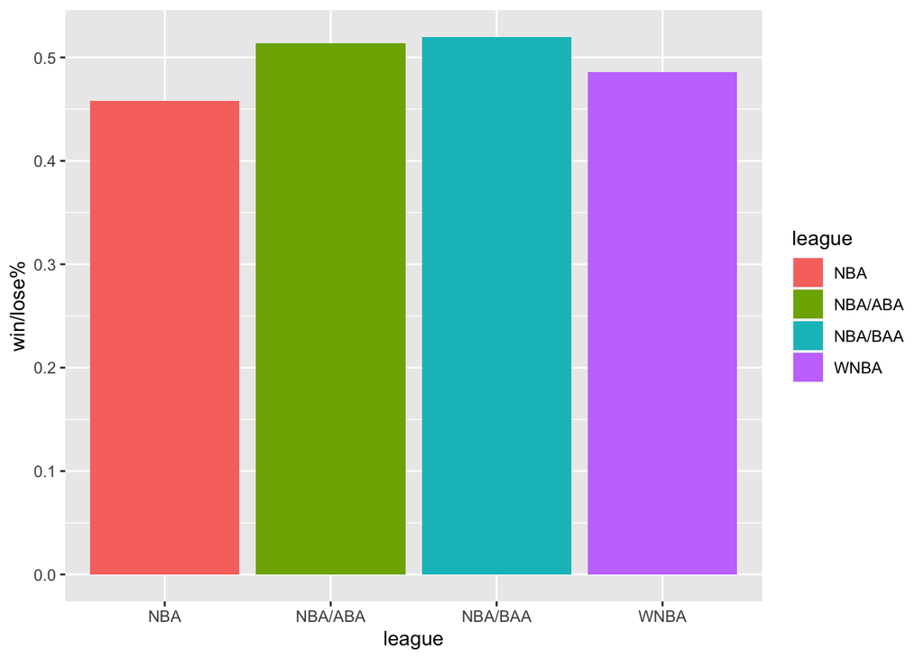

```r
# Plot 1

# is it easier to be successfull in any particular league?

plot1_data <-  aggregate(`win/lose%` ~ league, df_all, mean)

ggplot(plot1_data, aes(league,`win/lose%`, fill = league)) +
  geom_col()
```

The above plot suggests that there were more successful teams in the BAA league (later became part of the NBA), however, we also need to consider the fact that teams which existed in BAA, have existed longer and played more games, thus there is a probability that such teams are more successful due to longevity.

# Plot 2: Longevity vs. Win/Lose Ratio

Based on our previous findings, let’s examine the association between longevity and win/lose %. He we are intersted in whether more playing years increase the probability of getting a championship.

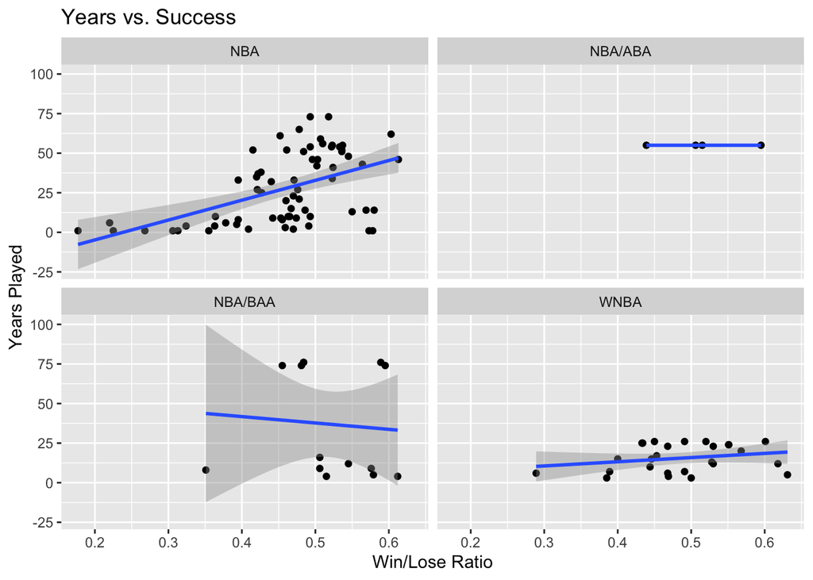

```r
# Plot 2
# longevity vs. success
ggplot(df_all,aes(`win/lose%`, yrs)) +
  geom_point() +
  geom_smooth(method = "lm") +
  facet_wrap(~ league) +
  labs(y="Years Played", x="Win/Lose Ratio", title="Years vs. Success")
```

It looks like, there are some significant differences in the association between longevity and win/lose % from league to league. The plot suggests, that in some cases (NBA/ABA and NBA/BAA) the association is flat or slightly negative, suggesting, that number of years played has no effect on success or can actually can have a negative effect. On the other hand, in the NBA and WBA, it looks like the association is actually positive. In orger to explain the league-based differences, we would need to take a look at some omitted variables.

# Plot 3: Teams with Most championships in NBA and WNBA

Next, let’s take a look at the teams with most championships. Since, we have the most observations in NBA and WNBA leagues, we compare the two.

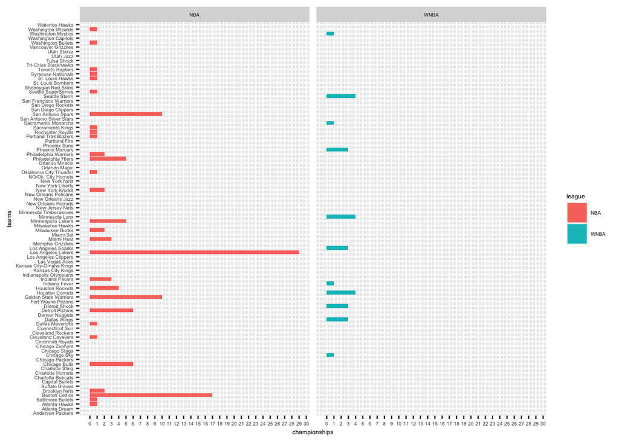

```r
# Plot 3
# which are the teams with most championships in different leagues
# let's see the franchises with most wins in the NBA and WNBA

plot2_data <- df_all %>%
  filter(league != "ABA",
         league != "BAA")

# converting the teams that transferred from other leagues to NBA
plot2_data <- plot2_data %>% mutate(league = str_remove(df_all$league, "/ABA"))
plot2_data <- plot2_data %>% mutate(league = str_remove(plot2_data$league, "/BAA"))

ggplot(plot2_data,aes(championships, teams, fill = league)) +
  geom_col() +
  facet_wrap(~ league) +
  scale_x_continuous(breaks=seq(0, 30, 1)) +
  theme(text = element_text(size=5), plot.title = element_text(size=15))
```

```r
  labs(x="Number of Championships", title="Championships by League")
```

```
## $x
## [1] "Number of Championships"
##
## $title
## [1] "Championships by League"
##
## attr(,"class")
## [1] "labels"
```

It looks like the LA Lakers and the BOS Celtics are the two most successful franchises in the NBA. In the WNBA the leaders are the Lynx, the Storm and the Comets (defunct), all having 4 championships a piece.

# Plot 4: Win/Lose Ratio vs. Championships

Let’s also examine the association between the number of championships and win/lose %, although we might expect it to be positive, there are instances when a team can perform really well in the regular season, but have little success in the playoffs.

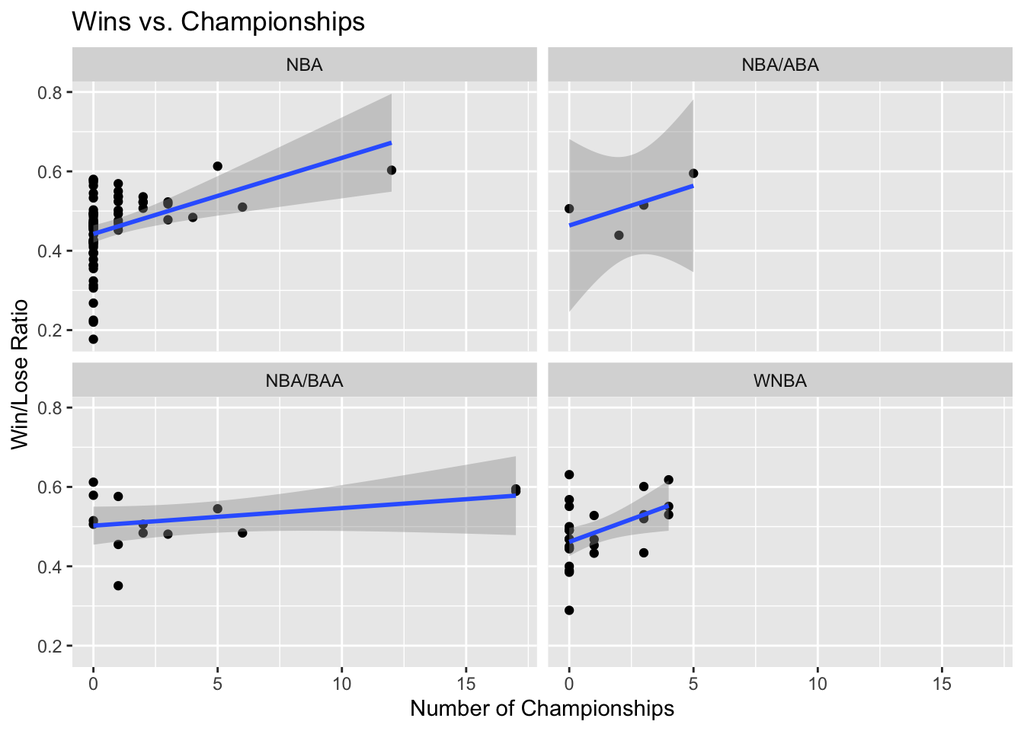

```r
# Plot 4
# see is the teams which perform well in general are more likely to win a championship

ggplot(df_all,aes(championships, `win/lose%`)) +
  geom_point() +
  geom_smooth(method = "lm") +
  scale_y_continuous(breaks=seq(0, 1, 0.20)) +
  facet_wrap(~ league) +
  labs(y="Win/Lose Ratio", x="Number of Championships", title="Wins vs. Championships")
```

As expected, in general, the association between the number of championships and win/lose ratio is positive across all the leagues.

# Plot 5: Playoffs vs. Championships

Finally, let’s take a look at how the association between playoff runs and championships looks like.

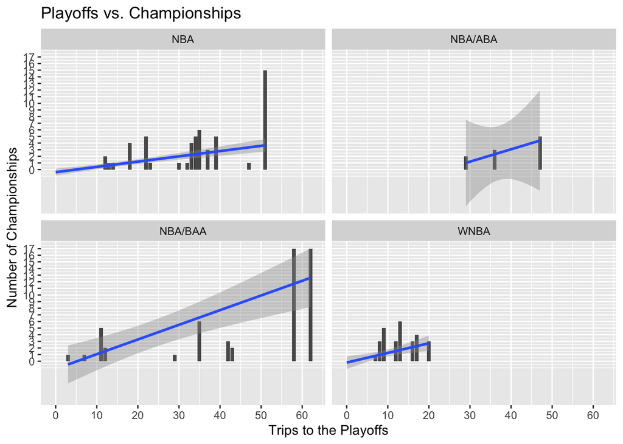

```r
# Plot 5
# how many playoffs to be more likely to win a championship
ggplot(df_all,aes(playoffs, championships)) +
geom_col() +
  geom_smooth(method = "lm") +
  facet_wrap(~ league) +
  scale_y_continuous(breaks=seq(0, 17, 1)) +
  scale_x_continuous(breaks=seq(0, 80, 10)) +
  labs(y="Number of Championships", x="Trips to the Playoffs", title="Playoffs vs. Championships")
```

Here, once again, the association is positive, suggesting that the more playoffs a team makes, the higher probability of winning a championships it has.

# Conclusion

In summary, when looking at the win/lose ratio, it seem like the league has some effect on it. For example based on the earlier, we could observe that it is somewhat harder to be successful in the NBA, than other leagues. Longevity appears to have different effects on win/lose ratio depending on the league. In order to discover the true association, we might need to examine some omitted variables. Finally, it looks like the expected metrics, such as win/lose ratio and number of trips to the playoffs might have positive effect on number of championships.